# Tutorial 13 — Advanced Features and Customisation

## 9 Extinction threshold — absorbing barrier for the atto-fox problem

ODE models assume continuous populations. A sub-threshold strain with a positive growth rate will eventually rebound once selection pressure is lifted — even if it was driven to 0.001 cells/mL, which is biologically nonsensical. This is the **atto-fox problem** (named for the fractional fox that never dies in continuous Lotka–Volterra ecology).

In a multi-strain model with resistance mutations, this is particularly problematic: a rare-genotype resistant strain seeded at 0.1 CFU/mL by the mutation matrix will eventually regrow to dominate after phage treatment ends, even if it was never realised as a physical bacterium during the entire experiment.

The `extinction_threshold` parameter in `solve_ode` implements an absorbing barrier:

| Level | When | Action |
| --- | --- | --- |
| **t = 0 (IC)** | Strain total < threshold at start | Zero it; emit `UserWarning` |
| **Between segments** | Strain total < threshold at a dose-event boundary | Zero it silently |
| **Output** | Strain first crosses below threshold at any time point | Zero all subsequent values |

```
result = solve_ode(model, t_end=72.0, dt=0.5,
                   extinction_threshold=1.0)   # 1 CFU/mL is the natural cutoff
```

A value of **1.0 CFU/mL** is biologically meaningful: below one cell per mL the well-mixed ODE approximation has already broken down, so zeroing at that point introduces no additional error.

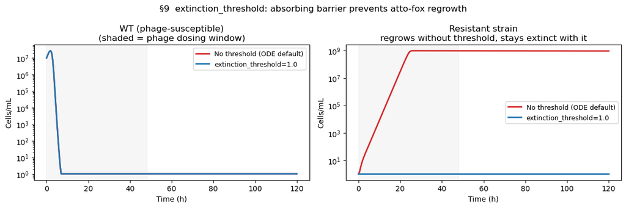

```
Resistant bacteria at t=120 h:
  No threshold:          9.36e+08 cells/mL
  extinction_threshold:  0.00e+00 cells/mL
```

```python
# ── BRG: WT + phage-resistant strain ─────────────────────────────────────────
bac_ext  = BacterialStrain(base_growth_rate=1.2, bacteria_to_resource_ratio=1e9)
phi_ext  = PhageStrain(
    name="phi0",
    adsorption_s=2e-9,   adsorption_r=2e-12,   # resistant has 1000× lower adsorption
    adsorption_dormant_s=0.0, adsorption_dormant_r=0.0,
    burst_size_s=50,     burst_size_r=50,
    latent_period_s=0.5, latent_period_r=0.5,
    latent_period_dormant_s=0.5, latent_period_dormant_r=0.5,
    fitness_cost=0.1,    mu=1e-7,   decay_rate=0.1,
)
brg_ext = BinaryResistanceGenotypes.from_strains(phages=[phi_ext], bacteria=bac_ext)

# Strains: [WT=0, Resistant=1].  Dose phage three times over 48 h, then watch to 120 h.
cfg_ext = brg_ext.to_config(
    n_latent=5, n_depth=1,
    monod_constant=0.3, recycle_fraction=0.5,
    dose_schedule=DoseSchedule([
        DoseEvent(time=t, amount=1e8, target="phage", index=0) for t in [0, 24, 48]
    ]),
)

# Resistant starts at 0.5 CFU/mL — generated by mutation matrix, biologically absent
B_init_ext = np.array([1e7, 0.5])

# ── No threshold: ODE continuity lets the resistant strain slowly grow back ───
res_no_thr = solve_ode(
    PBIModel(cfg_ext, initial_B=B_init_ext, initial_P=np.zeros(1), initial_S=1.0),
    t_end=120.0, dt=0.5,
    extinction_threshold=None,
)

# ── extinction_threshold=1.0: 0.5 CFU/mL is zeroed at t=0 and stays zero ─────
with warnings.catch_warnings():
    warnings.simplefilter("ignore", UserWarning)   # suppress IC warning for plot clarity
    res_thr = solve_ode(
        PBIModel(cfg_ext, initial_B=B_init_ext, initial_P=np.zeros(1), initial_S=1.0),
        t_end=120.0, dt=0.5,
        extinction_threshold=1.0,
    )

fig, axes = plt.subplots(1, 2, figsize=(12, 4))

for res, color, label in [
    (res_no_thr, "C3", "No threshold (ODE default)"),
    (res_thr,    "C0", "extinction_threshold=1.0"),
]:
    axes[0].semilogy(res.time, np.maximum(res.get("B0"), 1), color=color, lw=2, label=label)
    axes[1].semilogy(res.time, np.maximum(res.get("B1"), 1), color=color, lw=2, label=label)

axes[0].axvspan(0, 48, alpha=0.07, color="gray")
axes[1].axvspan(0, 48, alpha=0.07, color="gray")
axes[0].set(xlabel="Time (h)", ylabel="Cells/mL",
            title="WT (phage-susceptible)\n(shaded = phage dosing window)")
axes[1].set(xlabel="Time (h)", ylabel="Cells/mL",
            title="Resistant strain\nregrows without threshold, stays extinct with it")
for ax in axes:
    ax.legend(fontsize=9)
plt.suptitle("§9  extinction_threshold: absorbing barrier prevents atto-fox regrowth")
plt.tight_layout()
plt.show()

print(f"Resistant bacteria at t=120 h:")
print(f"  No threshold:          {res_no_thr.get('B1')[-1]:.2e} cells/mL")
print(f"  extinction_threshold:  {res_thr.get('B1')[-1]:.2e} cells/mL")
```

## 10 Immune CR/CS — per-genotype immune killing and stimulation

The standard model assigns a single `imm_kill_rate` and `imm_stim_rate` to all bacterial strains. Phage-resistance mutations often alter surface structures (outer-membrane proteins, LPS) that are also recognised by the innate immune system — so resistance to phage can be accompanied by altered immune susceptibility:

- **Cross-resistance (CR):** the same mutation reduces phagocytosis or pattern-recognition (value `< 1`). Common for mutations that down-regulate surface receptors.
- **Collateral sensitivity (CS):** resistance mutations expose new PAMPs or increase membrane permeability (value `> 1`).

Two new `BinaryResistanceGenotypes` parameters use the same log-linear formula as all other CR/CS parameters:

```
imm_kill_rate_eff[s] = imm_kill_rate_base  ×  exp( G[s, :] @ log(cr_imm_kill_rate) )
imm_stim_rate_eff[s] = imm_stim_rate_base  ×  exp( G[s, :] @ log(cr_imm_stim_rate) )
```

where `G[s, :]` is the full genotype vector (length `n_loci = n_phages + n_antibiotics`).

| Parameter | Shape | Meaning |
| --- | --- | --- |
| `cr_imm_kill_rate` | `(n_loci,)` | Kill-rate multiplier per resistance locus |
| `cr_imm_stim_rate` | `(n_loci,)` | Stim-rate multiplier per resistance locus |

```
brg = BinaryResistanceGenotypes.from_strains(
    phages=[phi0], bacteria=bac,
    cr_imm_kill_rate=np.array([0.3]),   # phage-resistance locus → 70% less immune killing
    cr_imm_stim_rate=np.array([0.5]),   # and 50% less immune stimulation
)
# to_config() picks up imm_kill_rate / imm_stim_rate as the base values
cfg = brg.to_config(n_latent=5, ...,
                    imm_kill_rate=3e6, imm_stim_rate=0.5, ...)
# cfg.imm_kill_rate → [3e6, 9e5]   (WT full rate; resistant 30% of base)
# cfg.imm_stim_rate → [0.5, 0.25]  (WT full rate; resistant 50% of base)
```

```
Effective immune kill rates:
  No CR/CS:  WT=3.00e+06,  Resistant=3.00e+06
  CR/CS:     WT=3.00e+06,  Resistant=9.00e+05  (30% of base)
Effective immune stim rates:
  No CR/CS:  WT=0.500,  Resistant=0.500
  CR/CS:     WT=0.500,  Resistant=0.250  (50% of base)
```

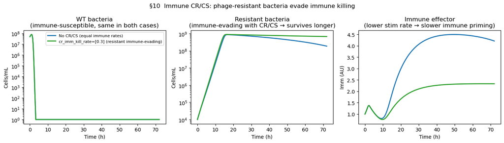

```python
# ── BRG without CR/CS (uniform immune rates) ──────────────────────────────────
brg_no_cr = BinaryResistanceGenotypes.from_strains(
    phages=[phi_ext], bacteria=bac_ext,
    # cr_imm_kill_rate=None (default) → both strains get the same imm_kill_rate
)

# ── BRG with immune CR/CS ──────────────────────────────────────────────────────
# cr_imm_kill_rate=[0.3]: phage-resistance locus reduces immune killing to 30%
# cr_imm_stim_rate=[0.5]: same locus also halves immune stimulation rate
brg_cr = BinaryResistanceGenotypes.from_strains(
    phages=[phi_ext], bacteria=bac_ext,
    cr_imm_kill_rate=np.array([0.3]),
    cr_imm_stim_rate=np.array([0.5]),
)

# Common immune and infection parameters
imm_kwargs = dict(
    imm_kill_rate=3e6, imm_stim_rate=0.5,
    imm_stim50=5e7,    imm_kill50=5e7,
    imm_decay_rate=0.1, immune_module="innate",
)
dose_kw = dict(
    n_latent=5, n_depth=1,
    monod_constant=0.3, recycle_fraction=0.0,
    dose_schedule=DoseSchedule([
        DoseEvent(time=0, amount=1e8, target="phage", index=0),
    ]),
)

cfg_no_cr = brg_no_cr.to_config(**dose_kw, **imm_kwargs)
cfg_cr    = brg_cr.to_config(**dose_kw, **imm_kwargs)

# Verify per-strain immune rates
print("Effective immune kill rates:")
print(f"  No CR/CS:  WT={cfg_no_cr.imm_kill_rate[0]:.2e},  Resistant={cfg_no_cr.imm_kill_rate[1]:.2e}")
print(f"  CR/CS:     WT={cfg_cr.imm_kill_rate[0]:.2e},  Resistant={cfg_cr.imm_kill_rate[1]:.2e}  (30% of base)")
print("Effective immune stim rates:")
print(f"  No CR/CS:  WT={cfg_no_cr.imm_stim_rate[0]:.3f},  Resistant={cfg_no_cr.imm_stim_rate[1]:.3f}")
print(f"  CR/CS:     WT={cfg_cr.imm_stim_rate[0]:.3f},  Resistant={cfg_cr.imm_stim_rate[1]:.3f}  (50% of base)")
print()

B_init_cr = np.array([5e7, 1e4])  # both strains at meaningful abundance

fig, axes = plt.subplots(1, 3, figsize=(14, 4))

for cfg, color, label in [
    (cfg_no_cr, "C0", "No CR/CS (equal immune rates)"),
    (cfg_cr,    "C2", "cr_imm_kill_rate=[0.3] (resistant immune-evading)"),
]:
    res = solve_ode(
        PBIModel(cfg, initial_B=B_init_cr, initial_P=np.zeros(1),
                 initial_S=1.0, initial_Imm=1.0),
        t_end=72.0, dt=0.25,
    )
    axes[0].semilogy(res.time, np.maximum(res.get("B0"), 1), color=color, lw=2, label=label)
    axes[1].semilogy(res.time, np.maximum(res.get("B1"), 1), color=color, lw=2)
    axes[2].plot(res.time, res.get("Imm"), color=color, lw=2)

axes[0].set(xlabel="Time (h)", ylabel="Cells/mL",
            title="WT bacteria\n(immune-susceptible, same in both cases)")
axes[1].set(xlabel="Time (h)", ylabel="Cells/mL",
            title="Resistant bacteria\n(immune-evading with CR/CS → survives longer)")
axes[2].set(xlabel="Time (h)", ylabel="Imm (AU)",
            title="Immune effector\n(lower stim rate → slower immune priming)")
axes[0].legend(fontsize=8)
plt.suptitle("§10  Immune CR/CS: phage-resistant bacteria evade immune killing")
plt.tight_layout()
plt.show()
```

## 11 Quick-reference: when to use each builder

```
Modelling goal                          → Recommended builder
──────────────────────────────────────────────────────────────
Single strain, prototype / tutorial     → ModelBuilder
Named clinical strains, per-strain abx  → StrainSet + StrainDefinition
All 2^m phage-resistance genotypes      → BinaryResistanceGenotypes.from_strains()
Quick 2-strain binary-resistance        → ModelBuilder + phage_resistance_rates=[μ]
```

## 12 Feature flag quick-reference

| Feature | Builder call | Default |
| --- | --- | --- |
| Superinfection | `.with_phage_params(allow_superinfection=True)` | `False` |
| Frozen nutrient | `.with_nutrient(track_nutrients=False)` | `True` |
| Dormant immune killing | `.with_immunity(imm_kill_rate_D=...)` | `None` |
| Dynamic switch | `.with_transition_function(fn)` | `None` |
| Custom lysis | `.with_lysis_function(fn)` | `None` |
| Phage spill-back | `PhagePKConfig(k_back=np.array([rate]))` | `None` |
| **OD measurement** | `.with_od_debris(u, v, kdis, od_to_cfu_conversion_factor=1.0)` | disabled |
| **Dormant IC (fraction)** | `PBIModel(..., dorm_frac=0.3)` or `InitialConditions(dorm_frac=...)` | `0` |
| **Dormant IC (explicit)** | `PBIModel(..., initial_D=arr)` or `InitialConditions(D=arr)` | zeros |
| **Stationary-phase IC** | `stationary_phase_ic(cfg, t_prerun=24.0)` — returns B, D, S, **Imm** | — |
| **Nutrient inflow** | `.with_nutrient(s_in=rate)` | `0.0` |
| **Nutrient washout** | `.with_nutrient(s_out=rate)` | `0.0` |
| **Extinction threshold** | `solve_ode(..., extinction_threshold=1.0)` | `None` |
| **Immune CR/CS** | `BinaryResistanceGenotypes.from_strains(..., cr_imm_kill_rate=..., cr_imm_stim_rate=...)` | `None` |

**Congratulations on completing the pbisim tutorial series.** You now have the tools to model phage–bacteria dynamics from a single-strain proof-of-concept (Tutorial 01) to a multi-arm clinical trial with inter-individual variability and systematic resistance genotype enumeration (Tutorials 11–12).

Further reading: `API_REFERENCE.md` in the repository root contains the complete parameter reference for every class and method.